# 视频教程和网页教程不能及时更新，一切以script为准！

## 注意：不要在tutorial/template/code/script.ipynb这里直接运行任何代码，可以把script.ipynb copy到你们的文件夹下面使用

## 复制script文件夹方法： 终端下运行`cpr ~/data/tutorial/template/code your_dir/`， 注意是cpr 不是 cp -r

# 运行以下代码块进行环境配置

### 无需修改，运行即可

```python
import importlib.util
import sys
import os
import pandas as pd
import numpy as np
from scipy.io import mmread, mmwrite
from scipy import sparse, io

sys.path.append('/home/ztr/abio_database_pipeline_new/')
from pipeline.datasets_curation import datasetBuilder
from pipeline.datasets_curation import inspector
my_builder = datasetBuilder.DatasetBuilder()
my_inspector = inspector.Inspector()
```

```python
my_builder.buildDataset()
```

```python
expressionMatrix_rawCounts = 'expressionMatrix_rawCounts.tsv'
expressionMatrix_normalized = 'expressionMatrix_normalized.tsv'
expressionMatrix_TPM = 'expressionMatrix_TPM.tsv'
cellAnnotation = 'cellAnnotation.tsv'
geneAnnotation = 'geneAnnotation.tsv'
unstructuredData = 'unstructuredData.json'
readme = 'README.json'
notAvailable = 'notAvailable'
```

# 1. 填写expressionMatrix_rawCounts.tsv

#### 矩阵填写注意事项！（适用于以下三种矩阵）：

矩阵的行名是cellID,列名可以是geneSymbol或者ensemblID，注意如果是ensemblID，需要去除版本号，即去掉小数点及小数点后面的数字。

### 1.1 读入标准模板查看格式

```python
df_raw = my_builder.read_template_tsv(expressionMatrix_rawCounts)
df_raw.head()
```

|  | cellID | geneSymbol1 | geneSymbol2 |
| --- | --- | --- | --- |

### 编写完成后应如下图所示

### 列名中，第一列为cellID, 其余列为基因名。

[figure not shown]

### 1.2 从 ../downloaded_data/ 路径中读取原始数据，进行清洗

```python
files = os.listdir('../downloaded_data/')
files
```

```
['GSE131272_D0-10x.csv.gz',
 'GSE131272_D2-10x.csv.gz',
 'GSE131272_D7-10x.csv.gz',
 'GSE131272_data-lesions.csv.gz',
 'GSE131272_D21-10x.csv.gz',
 'GSE131272_data-cuts.csv.gz',
 'GSE131272_D75-10x.csv.gz']
```

```python
#定义一个返回矩阵的函数
def get_matrix(filePath):
    raw = pd.read_csv('../downloaded_data/'+filePath,sep=',',index_col=0)
    df = raw.T
    df = df.reset_index()
    df = df.rename(columns={'index':'cellID'})
    return df
```

```python
D010x = get_matrix(files[0])
D210x = get_matrix(files[1])
D710x = get_matrix(files[2])
lesions = get_matrix(files[3])
D2110x = get_matrix(files[4])
cuts = get_matrix(files[5])
D7510x = get_matrix(files[6])
```

```python
merged_raw = pd.concat([D010x,D210x,D710x,lesions,D2110x,cuts,D7510x],join='inner')
```

### 1.3 清洗完成后，确认当前格式与目标格式相同，存储数据

```python
my_builder.save_template_tsv(merged_raw, expressionMatrix_rawCounts)
```

```
'overwritten expressionMatrix_rawCounts.tsv'
```

# 2. 填写expressionMatrix_normalized.tsv

### 2.1 读入标准模板查看格式

```python
#无norm数据
```

# 3. 填写expressionMatrix_TPM.tsv

#### TPM填写注意事项：

1.如果原文只提供了rawCounts矩阵，则使用6中的自动化函数生成

2.如果原文提供了normalized矩阵，则由normalizedMethod推导生成TPM矩阵

### 3.1 读入标准模板查看格式

```python
#TPM自动生成
```

# 4. 填写cellAnnotation.tsv

#### 注：如果你的数据找不到cluster信息，请使用我们的邮件模板发邮件给作者询问，如仍无回应，填为notAvailable

### 4.1 读入标准模板查看格式

```python
df_cell = my_builder.read_template_tsv(cellAnnotation)
df_cell.head()
```

|  | cellID | clusterID | clusterName | sampleID | cellOntologyName | cellOntologyID | meta_sourceName | meta_description | FACSMarker | tSNE1 | ... | meta_title | meta_strain | meta_age | meta_genotype | clusteringMethod | stats_numberOfTotalCounts | stats_numberOfGenes | stats_mitoPercent | meta_sex(computationallyDerived) | meta_scibetTabulaMuris |
| --- | --- | --- | --- | --- | --- | --- | --- | --- | --- | --- | --- | --- | --- | --- | --- | --- | --- | --- | --- | --- | --- |
| 0 | AAACCTGAGGCAGGTT.C10x | 9 | cluster_9 | GSM3768368 | notAvailable | notAvailable | trigeminal nuclei | notAvailable | notAvailable | 45.403699 | ... | WT_TG_5_10x | C57BL | > 6 wks | wildtype | louvain | 5643 | 2676 | 0.194932 | female | hepatocytes |
| 1 | AAACCTGCACGAAACG.C10x | 9 | cluster_9 | GSM3768368 | notAvailable | notAvailable | trigeminal nuclei | notAvailable | notAvailable | 44.996382 | ... | WT_TG_5_10x | C57BL | > 6 wks | wildtype | louvain | 2369 | 1320 | 0.084424 | female | hepatocytes |
| 2 | AAACGGGAGTAGCCGA.C10x | 9 | cluster_9 | GSM3768368 | notAvailable | notAvailable | trigeminal nuclei | notAvailable | notAvailable | 46.145342 | ... | WT_TG_5_10x | C57BL | > 6 wks | wildtype | louvain | 2702 | 1583 | 0.259067 | female | hepatocytes |
| 3 | AAAGATGGTCACTTCC.C10x | 9 | cluster_9 | GSM3768368 | notAvailable | notAvailable | trigeminal nuclei | notAvailable | notAvailable | 49.837119 | ... | WT_TG_5_10x | C57BL | > 6 wks | wildtype | louvain | 6010 | 3021 | 0.881864 | female | hepatocytes |
| 4 | AAAGATGTCCACGTTC.C10x | 9 | cluster_9 | GSM3768368 | notAvailable | notAvailable | trigeminal nuclei | notAvailable | notAvailable | 49.644339 | ... | WT_TG_5_10x | C57BL | > 6 wks | wildtype | louvain | 10811 | 4284 | 0.665988 | female | hepatocytes |

5 rows × 29 columns

### 编写完成后应如下图所示

[figure not shown]

### 4.2 将expressionMatrix_TPM.tsv 中的cellID填在cellAnnotation.tsv中

```python
tpm_cellID = pd.read_csv('../processed_data/expressionMatrix_TPM.tsv',sep='\t',usecols=[1])
tpm_cellID
```

|  | cellID |
| --- | --- |
| 0 | AAACCTGAGGCAGGTT.C10x |
| 1 | AAACCTGCACGAAACG.C10x |
| 2 | AAACGGGAGTAGCCGA.C10x |
| 3 | AAAGATGGTCACTTCC.C10x |
| 4 | AAAGATGTCCACGTTC.C10x |
| ... | ... |
| 37176 | TTTGTCAGTGATAAGT.D75 |
| 37177 | TTTGTCAGTGTGAATA.D75 |
| 37178 | TTTGTCATCCGCAGTG.D75 |
| 37179 | TTTGTCATCCTTGGTC.D75 |
| 37180 | TTTGTCATCTCAACTT.D75 |

37181 rows × 1 columns

### 4.3 根据对应的cellID填写其他列

#### sampleID需要和cellID一一对应，一般可通过title进行对应，如确实无法对应，填为notAvailable

#### meta字段为选填，填写时注意：

1.根据sample中的信息选择填写，除了模板中给的三个字段示例之外，需要自行添加，一般为其Characteristics的几个属性，可以先浏览GSM的界面查看，确定之后从sample里面摘下来

2.模板中的只是示例，如果没有该字段信息的请删除！不确定要不要填的请咨询管理员，切不可遗漏！

3.字段命名方式参考meta_sourceName，中间不要出现空格和其他连接符号，第二个单词开始才大写之前都小写，比如cell type命名为meta_cellType

4.有些数据在文章的supplementary data里面也有关于sample或是细胞的注释信息，这部分很重要，必须自行下载并填写进去

5.注意clusterName里面不能包含英文字符'.', 如果有请替换为'_'

```python
#若无该文件，则使用内置函数获取
sample = my_builder.sample_info(GSE = 'GSE131272')
sample
```

[output not shown]

|  | title | geo_accession | status | submission_date | last_update_date | type | channel_count | source_name_ch1 | organism_ch1 | taxid_ch1 | ... | contact_zip/postal_code | contact_country | instrument_model | library_selection | library_source | library_strategy | relation | supplementary_file_1 | series_id | data_row_count |
| --- | --- | --- | --- | --- | --- | --- | --- | --- | --- | --- | --- | --- | --- | --- | --- | --- | --- | --- | --- | --- | --- |
| GSM3768364 | WT_TG_1_DropSeq | GSM3768364 | Public on Oct 04 2019 | May 15 2019 | Oct 04 2019 | SRA | 1 | trigeminal nuclei | Mus musculus | 10090 | ... | 20892 | USA | Illumina MiSeq | size fractionation | transcriptomic | ncRNA-Seq | BioSample: https://www.ncbi.nlm.nih.gov/biosam... | NONE | GSE131272 | 0 |
| GSM3768365 | WT_TG_2_DropSeq | GSM3768365 | Public on Oct 04 2019 | May 15 2019 | Oct 04 2019 | SRA | 1 | trigeminal nuclei | Mus musculus | 10090 | ... | 20892 | USA | Illumina MiSeq | size fractionation | transcriptomic | ncRNA-Seq | BioSample: https://www.ncbi.nlm.nih.gov/biosam... | NONE | GSE131272 | 0 |
| GSM3768366 | WT_TG_3_DropSeq | GSM3768366 | Public on Oct 04 2019 | May 15 2019 | Oct 04 2019 | SRA | 1 | trigeminal nuclei | Mus musculus | 10090 | ... | 20892 | USA | Illumina MiSeq | size fractionation | transcriptomic | ncRNA-Seq | BioSample: https://www.ncbi.nlm.nih.gov/biosam... | NONE | GSE131272 | 0 |
| GSM3768367 | WT_TG_4_DropSeq | GSM3768367 | Public on Oct 04 2019 | May 15 2019 | Oct 04 2019 | SRA | 1 | trigeminal nuclei | Mus musculus | 10090 | ... | 20892 | USA | Illumina NextSeq 500 | size fractionation | transcriptomic | ncRNA-Seq | BioSample: https://www.ncbi.nlm.nih.gov/biosam... | NONE | GSE131272 | 0 |
| GSM3768368 | WT_TG_5_10x | GSM3768368 | Public on Oct 04 2019 | May 15 2019 | Oct 04 2019 | SRA | 1 | trigeminal nuclei | Mus musculus | 10090 | ... | 20892 | USA | Illumina NextSeq 500 | size fractionation | transcriptomic | ncRNA-Seq | BioSample: https://www.ncbi.nlm.nih.gov/biosam... | NONE | GSE131272 | 0 |
| GSM3768369 | SNI_2dpi | GSM3768369 | Public on Oct 04 2019 | May 15 2019 | Oct 04 2019 | SRA | 1 | trigeminal nuclei | Mus musculus | 10090 | ... | 20892 | USA | Illumina NextSeq 500 | size fractionation | transcriptomic | ncRNA-Seq | BioSample: https://www.ncbi.nlm.nih.gov/biosam... | NONE | GSE131272 | 0 |
| GSM3768370 | SNI_7dpi | GSM3768370 | Public on Oct 04 2019 | May 15 2019 | Oct 04 2019 | SRA | 1 | trigeminal nuclei | Mus musculus | 10090 | ... | 20892 | USA | Illumina NextSeq 500 | size fractionation | transcriptomic | ncRNA-Seq | BioSample: https://www.ncbi.nlm.nih.gov/biosam... | NONE | GSE131272 | 0 |
| GSM3768371 | SNI_21dpi | GSM3768371 | Public on Oct 04 2019 | May 15 2019 | Oct 04 2019 | SRA | 1 | trigeminal nuclei | Mus musculus | 10090 | ... | 20892 | USA | Illumina NextSeq 500 | size fractionation | transcriptomic | ncRNA-Seq | BioSample: https://www.ncbi.nlm.nih.gov/biosam... | NONE | GSE131272 | 0 |
| GSM3768372 | SNI_75dpi | GSM3768372 | Public on Oct 04 2019 | May 15 2019 | Oct 04 2019 | SRA | 1 | trigeminal nuclei | Mus musculus | 10090 | ... | 20892 | USA | Illumina NextSeq 500 | size fractionation | transcriptomic | ncRNA-Seq | BioSample: https://www.ncbi.nlm.nih.gov/biosam... | NONE | GSE131272 | 0 |
| GSM3768373 | itch_lesions | GSM3768373 | Public on Oct 04 2019 | May 15 2019 | Oct 04 2019 | SRA | 1 | trigeminal nuclei | Mus musculus | 10090 | ... | 20892 | USA | Illumina NextSeq 500 | size fractionation | transcriptomic | ncRNA-Seq | BioSample: https://www.ncbi.nlm.nih.gov/biosam... | NONE | GSE131272 | 0 |
| GSM3768374 | facial injury | GSM3768374 | Public on Oct 04 2019 | May 15 2019 | Oct 04 2019 | SRA | 1 | trigeminal nuclei | Mus musculus | 10090 | ... | 20892 | USA | Illumina NextSeq 500 | size fractionation | transcriptomic | ncRNA-Seq | BioSample: https://www.ncbi.nlm.nih.gov/biosam... | NONE | GSE131272 | 0 |

11 rows × 33 columns

GSM3768368 WT_TG_5_10x

GSM3768369 SNI_2dpi

GSM3768370 SNI_7dpi

GSM3768371 SNI_21dpi

GSM3768372 SNI_75dpi

GSM3768373 itch_lesions

GSM3768374 facial injury

```python
cuts = pd.read_csv('../downloaded_data/GSE131272_D75-10x.csv.gz',sep=',',nrows=2)
cuts
```

|  | Unnamed: 0 | AAACCTGGTCGCATCG.D75 | AAACCTGTCAGGTAAA.D75 | AAACCTGTCATTCACT.D75 | AAACGGGAGAACTCGG.D75 | AAACGGGAGATTACCC.D75 | AAACGGGAGCGGATCA.D75 | AAACGGGAGGTAAACT.D75 | AAACGGGCAATTGCTG.D75 | AAACGGGCACATGGGA.D75 | ... | TTTGTCAAGGCAATTA.D75 | TTTGTCAGTATAGGGC.D75 | TTTGTCAGTCATATGC.D75 | TTTGTCAGTCCAGTGC.D75 | TTTGTCAGTCCTCTTG.D75 | TTTGTCAGTGATAAGT.D75 | TTTGTCAGTGTGAATA.D75 | TTTGTCATCCGCAGTG.D75 | TTTGTCATCCTTGGTC.D75 | TTTGTCATCTCAACTT.D75 |
| --- | --- | --- | --- | --- | --- | --- | --- | --- | --- | --- | --- | --- | --- | --- | --- | --- | --- | --- | --- | --- | --- |
| 0 | Xkr4 | 0 | 2 | 1 | 1 | 1 | 2 | 1 | 1 | 1 | ... | 2 | 2 | 0 | 0 | 0 | 1 | 2 | 0 | 1 | 3 |
| 1 | Gm1992 | 0 | 0 | 0 | 0 | 0 | 0 | 0 | 0 | 0 | ... | 0 | 0 | 0 | 0 | 0 | 0 | 0 | 0 | 0 | 0 |

2 rows × 3635 columns

```python
tpm_cellID['sampleID'] = tpm_cellID['cellID'].apply(lambda x:'GSM3768368' if x.split('.')[-1]=='C10x' else('GSM3768369' if x.split('_')[0]=='D2' else('GSM3768370' if x.split('_')[0]=='D7' else('GSM3768371' if x.split('_')[0]=='D21' else('GSM3768372' if x.split('.')[-1]=='D75' else('GSM3768373' if x.split('.')[-1]=='cuts' else('GSM3768374')))))))
tpm_cellID
```

|  | cellID | sampleID |
| --- | --- | --- |
| 0 | AAACCTGAGGCAGGTT.C10x | GSM3768368 |
| 1 | AAACCTGCACGAAACG.C10x | GSM3768368 |
| 2 | AAACGGGAGTAGCCGA.C10x | GSM3768368 |
| 3 | AAAGATGGTCACTTCC.C10x | GSM3768368 |
| 4 | AAAGATGTCCACGTTC.C10x | GSM3768368 |
| ... | ... | ... |
| 37176 | TTTGTCAGTGATAAGT.D75 | GSM3768372 |
| 37177 | TTTGTCAGTGTGAATA.D75 | GSM3768372 |
| 37178 | TTTGTCATCCGCAGTG.D75 | GSM3768372 |
| 37179 | TTTGTCATCCTTGGTC.D75 | GSM3768372 |
| 37180 | TTTGTCATCTCAACTT.D75 | GSM3768372 |

37181 rows × 2 columns

```python
set(tpm_cellID['sampleID'].tolist())
```

```
{'GSM3768368',
 'GSM3768369',
 'GSM3768370',
 'GSM3768371',
 'GSM3768372',
 'GSM3768373',
 'GSM3768374'}
```

```python
cellID_info = pd.merge(tpm_cellID,sample,left_on='sampleID',right_on='geo_accession',how='left')
cellID_info.iloc[0]
```

```
cellID                                                                  AAACCTGAGGCAGGTT.C10x
sampleID                                                                           GSM3768368
title                                                                             WT_TG_5_10x
geo_accession                                                                      GSM3768368
status                                                                  Public on Oct 04 2019
submission_date                                                                   May 15 2019
last_update_date                                                                  Oct 04 2019
type                                                                                      SRA
channel_count                                                                               1
source_name_ch1                                                             trigeminal nuclei
organism_ch1                                                                     Mus musculus
taxid_ch1                                                                               10090
characteristics_ch1.0.strain                                                            C57BL
characteristics_ch1.1.age                                                             > 6 wks
characteristics_ch1.2.genotype/variation                                             wildtype
molecule_ch1                                                                        total RNA
extract_protocol_ch1                        Trigeminal ganglia were harvested and incubate...
description                                                            wildtype TG,D0-10x.csv
data_processing                             bcl2fastq (v2.17) was used for basecalling,Seq...
platform_id                                                                          GPL19057
contact_name                                                                    Minh,Q,Nguyen
contact_institute                                                                   NIDCR/NIH
contact_address                                                          9000, Rockville Pike
contact_city                                                                         Bethesda
contact_state                                                                        MARYLAND
contact_zip/postal_code                                                                 20892
contact_country                                                                           USA
instrument_model                                                         Illumina NextSeq 500
library_selection                                                          size fractionation
library_source                                                                 transcriptomic
library_strategy                                                                    ncRNA-Seq
relation                                    BioSample: https://www.ncbi.nlm.nih.gov/biosam...
supplementary_file_1                                                                     NONE
series_id                                                                           GSE131272
data_row_count                                                                              0
Name: 0, dtype: object
```

```python
df_cell = df_cell.drop(columns=['meta_tissue'])
df_cell
```

|  | cellID | clusterID | clusterName | sampleID | cellOntologyName | cellOntologyID | meta_sourceName | meta_description | FACSMarker | tSNE1 | ... | meta_title | meta_strain | meta_age | meta_genotype | clusteringMethod | stats_numberOfTotalCounts | stats_numberOfGenes | stats_mitoPercent | meta_sex(computationallyDerived) | meta_scibetTabulaMuris |
| --- | --- | --- | --- | --- | --- | --- | --- | --- | --- | --- | --- | --- | --- | --- | --- | --- | --- | --- | --- | --- | --- |
| 0 | AAACCTGAGGCAGGTT.C10x | 9 | cluster_9 | GSM3768368 | notAvailable | notAvailable | trigeminal nuclei | notAvailable | notAvailable | 45.403699 | ... | WT_TG_5_10x | C57BL | > 6 wks | wildtype | louvain | 5643 | 2676 | 0.194932 | female | hepatocytes |
| 1 | AAACCTGCACGAAACG.C10x | 9 | cluster_9 | GSM3768368 | notAvailable | notAvailable | trigeminal nuclei | notAvailable | notAvailable | 44.996382 | ... | WT_TG_5_10x | C57BL | > 6 wks | wildtype | louvain | 2369 | 1320 | 0.084424 | female | hepatocytes |
| 2 | AAACGGGAGTAGCCGA.C10x | 9 | cluster_9 | GSM3768368 | notAvailable | notAvailable | trigeminal nuclei | notAvailable | notAvailable | 46.145342 | ... | WT_TG_5_10x | C57BL | > 6 wks | wildtype | louvain | 2702 | 1583 | 0.259067 | female | hepatocytes |
| 3 | AAAGATGGTCACTTCC.C10x | 9 | cluster_9 | GSM3768368 | notAvailable | notAvailable | trigeminal nuclei | notAvailable | notAvailable | 49.837119 | ... | WT_TG_5_10x | C57BL | > 6 wks | wildtype | louvain | 6010 | 3021 | 0.881864 | female | hepatocytes |
| 4 | AAAGATGTCCACGTTC.C10x | 9 | cluster_9 | GSM3768368 | notAvailable | notAvailable | trigeminal nuclei | notAvailable | notAvailable | 49.644339 | ... | WT_TG_5_10x | C57BL | > 6 wks | wildtype | louvain | 10811 | 4284 | 0.665988 | female | hepatocytes |
| ... | ... | ... | ... | ... | ... | ... | ... | ... | ... | ... | ... | ... | ... | ... | ... | ... | ... | ... | ... | ... | ... |
| 37176 | TTTGTCAGTGATAAGT.D75 | 1 | cluster_1 | GSM3768372 | notAvailable | notAvailable | trigeminal nuclei | notAvailable | notAvailable | -36.992030 | ... | SNI_75dpi | C57BL | > 6 wks | spared nerve injury | louvain | 3211 | 1676 | 0.093429 | female | hepatocytes |
| 37177 | TTTGTCAGTGTGAATA.D75 | 3 | cluster_3 | GSM3768372 | notAvailable | notAvailable | trigeminal nuclei | notAvailable | notAvailable | -19.333470 | ... | SNI_75dpi | C57BL | > 6 wks | spared nerve injury | louvain | 2694 | 1575 | 0.037120 | female | hepatocytes |
| 37178 | TTTGTCATCCGCAGTG.D75 | 11 | cluster_11 | GSM3768372 | notAvailable | notAvailable | trigeminal nuclei | notAvailable | notAvailable | -12.720243 | ... | SNI_75dpi | C57BL | > 6 wks | spared nerve injury | louvain | 3482 | 2137 | 0.172315 | female | hepatocytes |
| 37179 | TTTGTCATCCTTGGTC.D75 | 2 | cluster_2 | GSM3768372 | notAvailable | notAvailable | trigeminal nuclei | notAvailable | notAvailable | 13.678943 | ... | SNI_75dpi | C57BL | > 6 wks | spared nerve injury | louvain | 4765 | 2258 | 0.083945 | female | hepatocytes |
| 37180 | TTTGTCATCTCAACTT.D75 | 2 | cluster_2 | GSM3768372 | notAvailable | notAvailable | trigeminal nuclei | notAvailable | notAvailable | 12.430277 | ... | SNI_75dpi | C57BL | > 6 wks | spared nerve injury | louvain | 2389 | 1339 | 0.041859 | female | hepatocytes |

37181 rows × 29 columns

```python
#填写sample metadata相关信息,字段名前面加上meta_,如meta_sourceName等,以下仅为示例，不是必填！
df_cell['cellID'] = cellID_info['cellID']
df_cell['sampleID'] = cellID_info['sampleID']
df_cell['meta_title'] = cellID_info['title']
df_cell['meta_title'] = cellID_info['title']
df_cell['meta_description'] = cellID_info['description']
df_cell['meta_strain'] = cellID_info['characteristics_ch1.0.strain']
df_cell['meta_age'] = cellID_info['characteristics_ch1.1.age']
df_cell['meta_genotype'] = cellID_info['characteristics_ch1.2.genotype/variation']
# .....
```

```python
df_cell['clusterID'] = 'notAvailable'
df_cell['clusterName'] = 'notAvailable'
df_cell['cellOntologyName'] = 'notAvailable'
df_cell['cellOntologyID'] = 'notAvailable'
df_cell['FACSMarker'] = 'notAvailable'
df_cell['tSNE1'] = 'notAvailable'# 从文章提供的表格或者其他数据来源中查找tSNE信息填入，若无再使用6中的函数生成
df_cell['tSNE2'] = 'notAvailable'
```

### 4.4 编辑完后保存

```python
df_cell
```

[output not shown]

37181 rows × 29 columns

```python
my_builder.save_template_tsv(df_cell, cellAnnotation)
```

```
overwritten confusion_meta.json
```

```
'overwritten cellAnnotation.tsv'
```

# 5 填写unstructuredData.json

### 5.1 读入并查看模板

```python
uns = my_builder.read_template_json(unstructuredData)
uns
```

```
{'metadata': {'datasetID': '',
  'subDataset': 'subDataset-4',
  'description': 'The original article contains 4 subdatasets, based on different samples. This subdataset is scRNA-seq analysis of trigeminal neurons from a combination of control uninjured mice; mice at day 2, day 7, day 21, day 75 after SNI; facial injury-day 2, and scratch lesion models.',
  'title': 'Stereotyped transcriptomic transformation of somatosensory neurons in response to injury',
  'authors': [{'lastname': 'Nguyen', 'firstname': 'Minh Q ', 'initials': 'MQ'},
   {'lastname': 'Le Pichon', 'firstname': 'Claire E ', 'initials': 'CE'},
   {'lastname': 'Ryba', 'firstname': 'Nicholas ', 'initials': 'N'}],
  'accessionNumber': 'GSE131272',
  'pubmedID': 31592768,
  'keywords': ['mouse',
   'neuroscience',
   'peripheral injury',
   'somatosensation',
   'spared nerve injury',
   'transcriptomic analysis',
   'transcriptomic plasticity',
   'trigeminal neurons'],
  'abstract': 'In mice, spared nerve injury replicates symptoms of human neuropathic pain and induces upregulation of many genes in somatosensory neurons. Here we used single cell transcriptomics to probe the effects of partial infraorbital transection of the trigeminal nerve at the cellular level. …
  'sourceID': 'https://doi.org/10.7554/eLife.49679',
  'numberOfCells': 0,
  'libraryPreparationMethod': '10x chromium',
  'sequencingPlatform': 'Illumina NextSeq 500',
  'clusteringMethod': 'Seurat',
  'biomarkerDerivationMethod': 'Seurat',
  'fastqURL': 'https://www.ncbi.nlm.nih.gov/bioproject/PRJNA543101',
  'figureURL': 'https://www.ncbi.nlm.nih.gov/pmc/articles/PMC6783272/bin/elife-49679-fig1.jpg',
  'isFigurePublic': 'True',
  'taxonomyID': 10090,
  'genomeBuild': 'mm10',
  'annotation': 'notAvailable',
  'journal': 'eLife',
  'publicationDate': '2019-10-08',
  'citation': 19,
  'tissue': ['trigeminal ganglion'],
  'tissueOntology': ['BTO:0001231'],
  'clusterAvailability': 'False',
  'disease': 'False',
  'methodology': 'False',
  'cancer': 'False',
  'neuroscience': 'True',
  'developmentalBiology': 'False',
  'immunology': 'False',
  'cellAtlas': 'True',
  'tSNEAvailability': 'False',
  'isBadtSNE': 'False',
  'cancerDescription': {},
  'diseaseOntologyName': [''],
  'diseaseOntologyID': [''],
  'isBadUMAP': 'False',
  'UMAPAvailability': 'False',
  'otherDataType': [''],
  'dataURL': '',
  'correspondingFigure': '5-a',
  'isTPMNotAvailable': 'False',
  'isCultured': 'False',
  'codeURL': 'notAvailable',
  'isDiseaseTreated': '',
  'numberOfSamples': 0,
  'isSelf-annotated': 'False'},
 'markerGenes': {}}
```

### unstructuredData.json 含有两部分，metadata和markerGenes

### 5.2 填写数据

#### metadata填写注意事项：

#### 部分字段会自动填充，可以运行查看，如有错误可以手动改正；其余字段需手动填上

#### libraryPreparationMethod需要填写注释中给定的几个字段之一，如果没有可以咨询管理员确认，不要乱填！也不要硬对上标准字段！

```python
metadata = uns['metadata']
metadata
```

```
{'datasetID': '',
 'subDataset': 'subDataset-4',
 'description': 'The original article contains 4 subdatasets, based on different samples. This subdataset is scRNA-seq analysis of trigeminal neurons from a combination of control uninjured mice; mice at day 2, day 7, day 21, day 75 after SNI; facial injury-day 2, and scratch lesion models.',
 'title': 'Stereotyped transcriptomic transformation of somatosensory neurons in response to injury',
 'authors': [{'lastname': 'Nguyen', 'firstname': 'Minh Q ', 'initials': 'MQ'},
  {'lastname': 'Le Pichon', 'firstname': 'Claire E ', 'initials': 'CE'},
  {'lastname': 'Ryba', 'firstname': 'Nicholas ', 'initials': 'N'}],
 'accessionNumber': 'GSE131272',
 'pubmedID': 31592768,
 'keywords': ['mouse',
  'neuroscience',
  'peripheral injury',
  'somatosensation',
  'spared nerve injury',
  'transcriptomic analysis',
  'transcriptomic plasticity',
  'trigeminal neurons'],
 'abstract': 'In mice, spared nerve injury replicates symptoms of human neuropathic pain and induces upregulation of many genes in somatosensory neurons. Here we used single cell transcriptomics to probe the effects of partial infraorbital transection of the trigeminal nerve at the cellular level. U…
 'sourceID': 'https://doi.org/10.7554/eLife.49679',
 'numberOfCells': 0,
 'libraryPreparationMethod': '10x chromium',
 'sequencingPlatform': 'Illumina NextSeq 500',
 'clusteringMethod': 'Seurat',
 'biomarkerDerivationMethod': 'Seurat',
 'fastqURL': 'https://www.ncbi.nlm.nih.gov/bioproject/PRJNA543101',
 'figureURL': 'https://www.ncbi.nlm.nih.gov/pmc/articles/PMC6783272/bin/elife-49679-fig1.jpg',
 'isFigurePublic': 'True',
 'taxonomyID': 10090,
 'genomeBuild': 'mm10',
 'annotation': 'notAvailable',
 'journal': 'eLife',
 'publicationDate': '2019-10-08',
 'citation': 19,
 'tissue': ['trigeminal ganglion'],
 'tissueOntology': ['BTO:0001231'],
 'clusterAvailability': 'False',
 'disease': 'False',
 'methodology': 'False',
 'cancer': 'False',
 'neuroscience': 'True',
 'developmentalBiology': 'False',
 'immunology': 'False',
 'cellAtlas': 'True',
 'tSNEAvailability': 'False',
 'isBadtSNE': 'False',
 'cancerDescription': {},
 'diseaseOntologyName': [''],
 'diseaseOntologyID': [''],
 'isBadUMAP': 'False',
 'UMAPAvailability': 'False',
 'otherDataType': [''],
 'dataURL': '',
 'correspondingFigure': '5-a',
 'isTPMNotAvailable': 'False',
 'isCultured': 'False',
 'codeURL': 'notAvailable',
 'isDiseaseTreated': '',
 'numberOfSamples': 0,
 'isSelf-annotated': 'False'}
```

```python
number_of_cells = my_builder.read_template_tsv(cellAnnotation).shape[0]
metadata['numberOfCells'] = number_of_cells
metadata['numberOfSamples'] = len(set(my_builder.read_template_tsv(cellAnnotation)['sampleID'])-{'notAvailable'})
metadata['numberOfSamples']
```

```
7
```

```python
pubmed_id = 31592768 # 注意填数字，不是字符串
metadata['pubmedID'] = pubmed_id
```

```python
pubmed_data = my_builder.get_pubmed_data(pubmed_id)
pubmed_data
```

```
{'title': 'Stereotyped transcriptomic transformation of somatosensory neurons in response to injury',
 'abstract': 'In mice, spared nerve injury replicates symptoms of human neuropathic pain and induces upregulation of many genes in somatosensory neurons. Here we used single cell transcriptomics to probe the effects of partial infraorbital transection of the trigeminal nerve at the cellular level. U…
 'sourceID': 'https://doi.org/10.7554/eLife.49679',
 'journal': 'eLife',
 'publicationDate': '2019-10-08',
 'authors': [{'lastname': 'Nguyen', 'firstname': 'Minh Q ', 'initials': 'MQ'},
  {'lastname': 'Le Pichon', 'firstname': 'Claire E ', 'initials': 'CE'},
  {'lastname': 'Ryba', 'firstname': 'Nicholas ', 'initials': 'N'}],
 'keywords': ['mouse',
  'neuroscience',
  'peripheral injury',
  'somatosensation',
  'spared nerve injury',
  'transcriptomic analysis',
  'transcriptomic plasticity',
  'trigeminal neurons']}
```

```python
# 自动填充部分，若自动填充部分出错，请改为手动填充相应字段
metadata['title'] = pubmed_data['title']
metadata['abstract'] = pubmed_data['abstract']
metadata['sourceID'] = pubmed_data['sourceID']
metadata['journal'] = pubmed_data['journal']
metadata['publicationDate'] = pubmed_data['publicationDate']
metadata['authors'] = pubmed_data['authors']
metadata['keywords'] = pubmed_data['keywords']

metadata['citation'] = my_builder.get_citation(metadata['sourceID']) # 引用次数
```

**当文章没有pubmed_id，有doi时，可运行以下代码填充authors，或者上面pubmed_id不能正确填充authors时可尝试用以下代码填充authors**

metadata['authors'] = my_builder.get_authors_by_doi(metadata['sourceID'])

```python
tissue = ['trigeminal ganglion']# 实验中用的tissue,从下面的tissue keywords中选填,或者填https://www.ebi.ac.uk/ols/ontologies/bto网站查到的tissueOntologyName
metadata['tissue'] = tissue
metadata['tissueOntology'] = my_builder.get_tissue_ontology(tissue)
```

```python
# 常见的tissue keywords
my_inspector.tissue_keywords
```

```
['adipose',
 'aorta',
 'bladder',
 'blood',
 'blood vessel',
 'bone',
 'bone marrow',
 'brain',
 'breast',
 'colon',
 'cerebral cortex',
 'diaphragm',
 'ear',
 'embryo',
 'eye',
 'hair',
 'heart',
 'kidney',
 'limb',
 'muscle',
 'lymphoid',
 'prostate',
 'neuron',
 'small intestine',
 'large intestine',
 'liver',
 'lung',
 'gland',
 'urethra',
 'testis',
 'pancreas',
 'skin',
 'spleen',
 'thymus',
 'tongue',
 'trachea']
```

```python
metadata['otherDataType'] = ['',] # 根据文章中是否出除了scRNA-seq的其他数据如：TCR, BCR, CyTOF, CITE-seq, spatial transcriptomics,total-seq,REAP-seq
```

```python
# 查看otherDataType keywords
my_inspector.other_data_type_keywords
```

```
['TCR',
 'BCR',
 'CyTOF',
 'CITE-seq',
 'spatial transcriptomics',
 'total-seq',
 'REAP-seq',
 'crispr']
```

```python
my_inspector.show_controlled_vocabulary()
```

[output not shown]

[output cut: 359 more lines]

```
  'PLoS pathogens',
  'Proceedings of the National Academy of Sciences of the United States of America',
  'Science',
  'Science advances',
  'Science immunology',
  'Science signaling',
  'Science translational medicine',
  'Scientific data',
  'Scientific reports',
  'Stem cell reports',
  'Stem cell research',
  'Theranostics',
  'bioRxiv',
  'eLife',
  'iScience']}
```

```python
metadata['subDataset'] = 'subDataset-4' # 如果有不只一个part，则根据part_n填为SubDataset-n；只有一个part不填
metadata['description'] = 'The original article contains 4 subdatasets, based on different samples. This subdataset is scRNA-seq analysis of trigeminal neurons from a combination of control uninjured mice; mice at day 2, day 7, day 21, day 75 after SNI; facial injury-day 2, and scratch lesion models.' # 对subDataset的描述，填写规则看下面注释；只有一个part不填
metadata['correspondingFigure'] = '5-a' # 这里填写该数据对应的文章tSNE聚类图，格式为形如"1-a"，意思为figure1的图a，没有对应的图填为notAvailable
metadata['accessionNumber'] = 'GSE131272'
metadata['libraryPreparationMethod'] = '10x chromium' # 从下面注释的对应部分中选填
metadata['sequencingPlatform'] = 'Illumina NextSeq 500' # 'Illumina HiSeq 2500'
metadata['clusteringMethod'] = 'Seurat'
metadata['biomarkerDerivationMethod'] = 'Seurat' # 是指marker gene的算法，一般在文章的method里面有，是找cluster下游的特异基因的方法。一般是t-test或者wilcoxon之类的，尽量在文章中找到对应的marker genes的算法。
metadata['fastqURL'] = 'https://www.ncbi.nlm.nih.gov/bioproject/PRJNA543101' # 如: https://www.ebi.ac.uk/ena/browser/view/PRJNAXXXXX
metadata['figureURL'] = 'https://www.ncbi.nlm.nih.gov/pmc/articles/PMC6783272/bin/elife-49679-fig1.jpg' # 使用文章的Graphical Abstract，如果没有则用第一张图Fig.1，链接需能在浏览器中打开
metadata['codeURL'] = 'notAvailable' # 如果作者提供了代码，需要把链接填写在这里。一般会在文献中的codeAvailability中找到github链接或者dropbox链接，里面有时会有cluster信息，请仔细查看。
metadata['dataURL'] = ''#非GSE数据没办法填写GSE开头的accession number的数据集需要填写此项。填写data来源的网址。
metadata['isFigurePublic'] = 'True'# 填True or False, 是否对所有网络均公开可见，如一般abstract中的figure为公开的
metadata['taxonomyID'] = 10090 # 人填9606， 鼠填10090
metadata['genomeBuild'] = 'mm10' # 'hg38'
metadata['annotation'] = 'notAvailable' # 是指基因的注释信息是什么,在GEO网站搜索，大多数时候是基因的版本号如ensembl_v93，但也有出现其他信息的情况，似乎被作者当作note信息来使用。
metadata['clusterAvailability'] = 'False'# 填True or False，意思是能否找到对应的cluster信息
# 以下字段为文章的研究主题，注意是字符串格式
metadata['disease'] = 'False' # 填True or False
metadata['methodology'] = 'False'# 填True or False
metadata['cancer'] = 'False'# 填True or False
metadata['neuroscience'] = 'True' # 填True or False
metadata['developmentalBiology'] = 'False'# 填True or False
metadata['immunology'] = 'False'# 填True or False
metadata['cellAtlas'] = 'True'# 填True or False
metadata['tSNEAvailability'] = 'False'# 填True or False,意思是能否找到tSNE的坐标信息，同样需要发邮件
metadata['isBadtSNE'] = 'False' # 填True or False,由6中的tSNEplot画出图形判断
metadata['UMAPAvailability'] = 'False'# 填True or False,意思是能否找到UMAP的坐标信息，同样需要发邮件
metadata['isBadUMAP'] = 'False'# 填True or False,由6中的UMAPplot画出图形判断
metadata['isCultured'] = 'False'# 填Ture or False, 意思是scRNA-seq所用的细胞是作者自己传代培养（True）的还是原代细胞（False）
metadata['isTPMNotAvailable'] = 'False'# 填True or False. Some articles provide norm matrix only and cannot generate TPM (we can only treat the norm as if it is TPM)，此时填上True。但在矩阵的normalizationMethod这一列里要标注清楚这个不是TPM矩阵！
metadata['isDiseaseTreated'] = '' # 当disease为True时需要填True or False, 意思是文章是否治疗该疾病, disease为False时, 留空即可
```

```python
# 若disease为True需要填diseaseOntologyName, 根据文章到https://disease-ontology.org/网站查找
# 若disease为False直接留空,并运行即可
disease_name = ['']
metadata['diseaseOntologyName'] = disease_name
metadata['diseaseOntologyID'] = my_builder.get_disease_ontology_id(disease_name)
```

```python
# 若cancer为True需要填写以下字段
cancerDescription = {}
cancerDescription['TIL'] = '' # 填 True or False.Tumor Infiltrating Lymphocyte肿瘤浸润淋巴细胞的缩写
cancerDescription['TIM'] = '' # 填 True or False.tumour infiltrating myeloid cell肿瘤浸润髓样细胞的缩写,与TIL并称为 tumour infiltrating immune cells (TII)
cancerDescription['TME'] = '' # 填 True or False.Tumor Micro-environment肿瘤微环境的缩写(non-immune cells, which we mean by cancer\ fibroblast, etc)
cancerDescription['NCIBodyLocation'] = '' # 从给的keywords选填, 如: Head and Neck
cancerDescription['NCIBodyLocationSubtype'] = '' # 根据NCIBodyLocatio对应的keywords选填, 如: Hypopharyngeal Cancer
cancerDescription['TCGAStudyAbbreviation'] = '' # 从给的keywords选填, 如: LAML
cancerDescription['TCGAStudyName'] = '' # TCGAStudyAbbreviation对应的全称如: LAML对应的全称为: Acute Myeloid Leukemia


# 运行 my_inspector.nci_cancer_typing 查看 NCIBodyLocatio的keywords
# 运行 my_inspector.tcga_cancer_typing 查看 TCGAStudy的keywords
```

```python
# 若cancer为False cancerDescription 填{}即可
cancerDescription = {}
```

```python
metadata['cancerDescription'] = cancerDescription
```

libraryPreparationMethod: 10x chromium,drop-seq,microwell-seq,C1 Fluidigm,inDrops,Smart-seq2,Smart-seq,CEL-seq,CEL-seq2,MARS-seq,msSCRB-seq,SCRB-seq.

journal: Cancer cell,Cancer discovery,Cell,Cell stem cell,Cell system,Immmunity,Molecular cell,Nature,Nature biomedical engineering,Nature cell biology,Nature communications,Nature genetics,Nature medicine,Nature methods,Nature neuroscience,Neuron,Science,Science immunology,Science translational medicine,eLife

description: The original article contains ? subdatasets, based on "e.g. different sequencing platforms", "e.g. adult & fatal tissue",. This subdataset is based on "e.g. smartseq-2", "adult tissue", (should match the initial description.)

如果你的数据不符合以上给定字符串，请告知管理员！

```python
# 存储数据
uns['metadata'] = metadata
my_builder.save_template_json(uns, unstructuredData)
```

```
'overwritten unstructuredData.json'
```

### 5.3 填写marker genes，由文章给的数据填写或者邮件发送作者询问

如果给的是geneSymbol,可使用my_builder.calculate_ensemblID(geneSymbol)得到对应的ensemblID；

如果给的是ensemblID,可使用my_builder.calculate_geneSymbol(ensemblID)得到对应的geneSymbol。

注：需要填写taxomomyID并保存，输入输出格式均为list

```python
# 查看模板格式
uns['markerGenes']
```

```
{}
```

```python
markerGenes = {}
```

```python
# 存储数据
uns['markerGenes'] = markerGenes
my_builder.save_template_json(uns, unstructuredData)
```

```
'overwritten unstructuredData.json'
```

# 6. 使用脚本自动生成其他项

### 以下几个函数需要按照顺序运行

### 6.1 由raw生成TPM都需要存成mtx格式（未提供normalized矩阵的情况下）

运行该命令需要首先填写unstruc文件中metadata部分的libraryPreparationMethod，如果libraryPreparationMethod在我们给定的标准字段（见上面的注释）中，则直接运行下面的命令，否则需要判断是否为全长测序，并加入参数gene_len = True or False.

如果raw counts存为sparse matrix，也可运行该函数由raw counts得到TPM，同时会自动生成geneAnnotation文件

```python
# generate TPM from rawCou
my_builder.toTPM()
```

### 6.2 生成geneAnnotation文件

#### 如果不能生成首先查下TPM矩阵的列名格式是否正确

#### 手动生成指定基因的geneAnnotation运行： my_builder.generate_geneAnno(isEnsemblID=, genes=)

#### 其中genes为需要生成的list, 若genes为ensembleID时, isEnsembleID需要设为: True

```python
my_builder.generate_geneAnno()
```

# 查看 geneAnnotation

#### geneAnnotation格式对后面的大部分步骤都有关，后面步骤运行出错请先检查geneAnnotation格式

#### 常见物种如：人和小鼠的geneAnnotation格式如下图所示

[figure not shown]

```python
df_gene = my_builder.read_template_tsv(geneAnnotation)
df_gene
```

|  | geneSymbol | ensemblID | ensemblIDVersion | geneID |
| --- | --- | --- | --- | --- |
| 0 | Xkr4 | ENSMUSG00000051951 | V90 | NaN |
| 1 | Gm1992 | ENSMUSG00000089699 | V90 | NaN |
| 2 | Rp1 | ENSMUSG00000025900 | V90 | NaN |
| 3 | Gm6085 | ENSMUSG00000098104 | V90 | NaN |
| 4 | Mrpl15 | ENSMUSG00000033845 | V90 | NaN |
| ... | ... | ... | ... | ... |
| 17607 | mt-Nd4l | ENSMUSG00000065947 | V90 | NaN |
| 17608 | mt-Nd4 | ENSMUSG00000064363 | V90 | NaN |
| 17609 | mt-Nd5 | ENSMUSG00000064367 | V90 | NaN |
| 17610 | mt-Nd6 | ENSMUSG00000064368 | V90 | NaN |
| 17611 | mt-Cytb | ENSMUSG00000064370 | V90 | NaN |

17612 rows × 4 columns

### 6.3 & 6.4 快速计算cluster 、tSNE和UMAP

#### 如果出错首先查下TPM格式是否正确，是否存在负值

```python
df_gene = my_builder.read_template_tsv(geneAnnotation)
df_gene
```

|  | geneSymbol | ensemblID | ensemblIDVersion | geneID |
| --- | --- | --- | --- | --- |
| 0 | Xkr4 | ENSMUSG00000051951 | V90 | NaN |
| 1 | Gm1992 | ENSMUSG00000089699 | V90 | NaN |
| 2 | Rp1 | ENSMUSG00000025900 | V90 | NaN |
| 3 | Gm6085 | ENSMUSG00000098104 | V90 | NaN |
| 4 | Mrpl15 | ENSMUSG00000033845 | V90 | NaN |
| ... | ... | ... | ... | ... |
| 17607 | mt-Nd4l | ENSMUSG00000065947 | V90 | NaN |
| 17608 | mt-Nd4 | ENSMUSG00000064363 | V90 | NaN |
| 17609 | mt-Nd5 | ENSMUSG00000064367 | V90 | NaN |
| 17610 | mt-Nd6 | ENSMUSG00000064368 | V90 | NaN |
| 17611 | mt-Cytb | ENSMUSG00000064370 | V90 | NaN |

17612 rows × 4 columns

### 6.3 & 6.4 快速计算cluster 、tSNE和UMAP

#### 如果出错首先查下TPM格式是否正确，是否存在负值

```python
# 参数说明：
# 1. cluster、tSNE、UMAP三个dict时计算三者的参数，如有不需要计算的，注释掉该行代码即可
# 2. over_write：默认为Fasle，若为False，而对应的cluster或者tsne或者umap不为空时，会提示选择是否覆盖，True则直接覆盖
# 3. tSNE和UMAP 的 method， 分别有'net_tsne'和'tsne'、'net_umap'和'umap'供选，其中'net_'开头的运算速度较快，但有可能会运算出错
# 'net_tsne'或者'net_umap' method 运行出错请替换method为'tsne' 或者 'umap'
# 4. dim_2 和 dim_3 指 2D 和 3D, 默认均为：True

param = [
    {'cluster': {'over_write': True}},

    {'tSNE': {'method': 'net_tsne', 'dim_2': True, 'dim_3': True, 'over_write': True}},

    {'UMAP': {'method': 'umap', 'dim_2': True, 'dim_3': True, 'over_write': True}},

]
my_builder.auto_run(param)
```

#### 画图判断isBadtSNE

如果图上的颜色混杂在一起，则为bad。

```python
my_builder.tSNEplot()
```

#### 画图判断isBadUMAP

如果图上的颜色混杂在一起，则为bad。

```python
my_builder.UMAPplot()
```

#### 画图判断genePlots

根据文章中给出的某些基因的tSNE/UMAP图，画出相同基因在此数据中的tSNE/UMAP图，只需要填写文章中使用的基因的即可，格式为list，若是没有基因可选，再尝试使用默认参数T_cell=True, B_cell=True画图。

```
house keeping genes GAPDH & Actb should be expressed in all cells,                    if not, report to admin that this dataset has quality issues
```

```
... storing 'clusterName' as categorical
```

```
WARNING: saving figure to file /disks/data/user_33/31592768/GSE131272/part_4/processed_data/figures/tsneGenesPlot.png
```

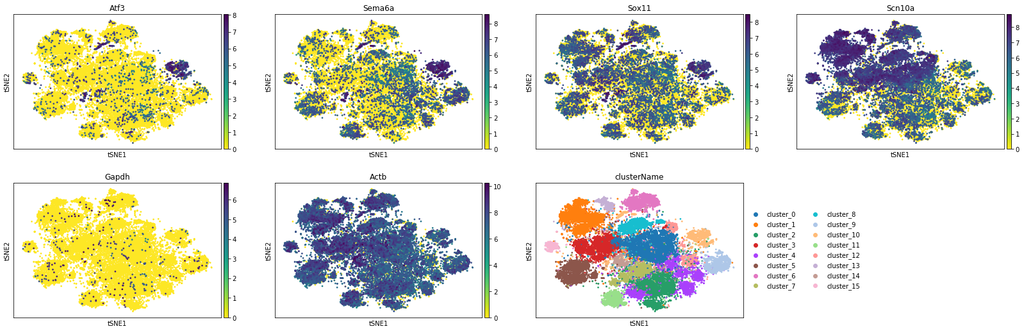

```
WARNING: saving figure to file /disks/data/user_33/31592768/GSE131272/part_4/processed_data/figures/umapGenesPlot.png
```

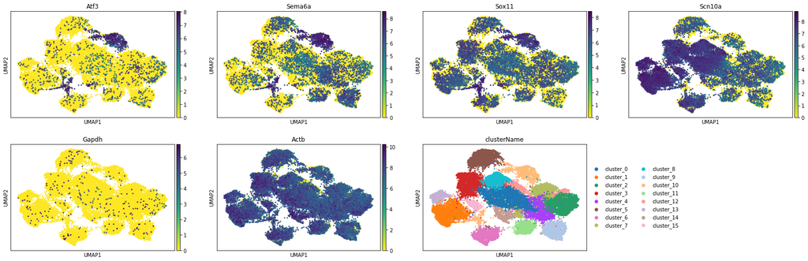

```python
my_builder.genes_plot(['Atf3','Sema6a','Sox11','Scn10a'], house_keeping=True, T_cell=False, B_cell=False)#['']中填写gene名字
```

### 6.5 生成cellontologyID

```python
my_builder.generate_ontology_id()
```

```
finished
overwritten confusion_meta.json
```

### 6.6 有rawCounts需要计算qc

```python
my_builder.calc_qc_value()
```

### 6.7 自动生成其他文件

```python
my_builder.auto_calculation(diff_genes=True,paga=True,scibet=True, gene_set=True)
```

### 6.8 若物种为人需要运行以下代码

```python
my_builder.calc_cell_cycle_score()
```

```python
my_builder.cpdb_statistical_analysis()
```

# 7. 填写README

```python
#读入模板
Readme = my_builder.read_template_json(readme)
Readme
```

```
{'qualityControl': 'notPassed',
 'author': '',
 'date': '',
 'modificationDate': '',
 'unfinishedParts': [''],
 'authorComments': '',
 'otherComments': '',
 'relationship': 'part_3是part_4的子集；part_1和part_3,4有交集；part_2与part_3,4交集；'}
```

```python
#更改信息
Readme['author'] = 'Lina Lu'
Readme['date'] = '2021-2-14'
Readme['modificationDate'] = ''
Readme['unfinishedParts'] = [''] #未完成的部分，包括矩阵及cellAnno中的cluster等
Readme['authorComments'] = 'The original article contains 4 subdatasets, based on different samples. This subdataset is scRNA-seq analysis of trigeminal neurons from a combination of control uninjured mice; mice at day 2, day 7, day 21, day 75 after SNI; facial injury-day 2, and scratch lesion models.' #如果数据分成了几个part，写清楚该part代表什么类型的数据
Readme['otherComments'] = '7个rawCounts文件取基因交集存为tsv，TPM由这个tsv自动生成，无cluster和markergene信息所以cluster自动生成。部分代码挂后台'
Readme['relationship'] = 'part_3是part_4的子集；part_1和part_3,4有交集；part_2与part_3,4交集；'
```

```python
#保存文件
my_builder.save_template_json(Readme, readme)
```

```
'overwritten README.json'
```

# 8. 使用检查器检查

### 8.1 运行如下代码，检查器会提示错误信息

```python
my_inspector.inspect() #注意看报ERROR的内容！
```

```
{'directory_hierarchy_results': {'present directory': '/disks/data/user_33/31592768/GSE131272/part_4/code'},
 'cell_annotation_result': {'cell_metadata_result': {'meta_age',
   'meta_description',
   'meta_genotype',
   'meta_scibetTabulaMuris',
   'meta_sex(computationallyDerived)',
   'meta_sourceName',
   'meta_strain',
   'meta_title'},
  'cluster': {'cluster derived from the pipeline'}},
 'gene_annotation_result': {},
 'unstructured_data': {'metadata_result': {'keyword_content': ['no content in isDiseaseTreated',
    'no content in dataURL']},
  'marker_genes_result': {'marker_gene_contents': 'no markers genes!'}},
 'raw_expression_matrix_result': {},
 'normalized_expression_matrix_result': {},
 'TPM_expression_matrix_result': {'normalizationMethod': 'TPM from raw data'},
 'dimension_result': {},
 'README_result': {'unfinished': [''],
  'comments': 'The original article contains 4 subdatasets, based on different samples. This subdataset is scRNA-seq analysis of trigeminal neurons from a combination of control uninjured mice; mice at day 2, day 7, day 21, day 75 after SNI; facial injury-day 2, and scratch lesion models.'},
 'print_line': {'cell_annotation': ['AAACCTGAGGCAGGTT.C10x',
   9,
   'cluster_9',
   'GSM3768368',
   'notAvailable',
   'notAvailable'],
  'gene_annotation': ['Xkr4', 'ENSMUSG00000051951']}}
```